# Week 12 Lab – Confidence Intervals in (G)LMM

Drew Tyre

November 6, 2016

This week we’ll continue to look at Linear and Generalized linear mixed effects models, emphasizing how to get confidence intervals on the predictions. We’ll start with something easy - a linear mixed effects model with the sleepstudy data.

```r
library(tidyverse)
library(lme4)  ## notice conflicts with tidyr
```

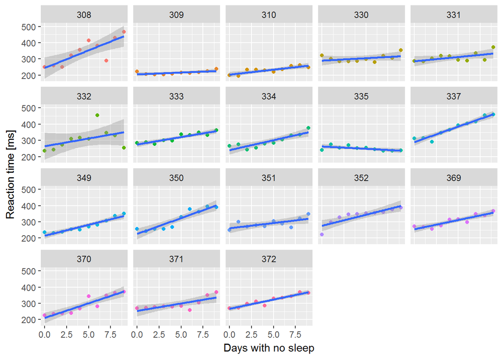

```r
library(broom)
library(boot)

ssBase <- ggplot(sleepstudy, aes(x = Days, y = Reaction)) + geom_point(aes(color = Subject)) +
    scale_color_discrete() + labs(x = "Days with no sleep", y = "Reaction time [ms]")
ssBase + geom_smooth(method = "lm") + facet_wrap(~Subject) + guides(color = FALSE)
```

So there’s the basic data, and now we fit a mixed model with both the intercept and Days varying across subjects.

```r
# fit a mixed model
summary(ss.mm <- lmer(Reaction ~ Days + (1 + Days | Subject), sleepstudy, REML = FALSE))
```

```
## Linear mixed model fit by maximum likelihood  ['lmerMod']
## Formula: Reaction ~ Days + (1 + Days | Subject)
##    Data: sleepstudy
##
##      AIC      BIC   logLik deviance df.resid
##   1763.9   1783.1   -876.0   1751.9      174
##
## Scaled residuals:
##     Min      1Q  Median      3Q     Max
## -3.9416 -0.4656  0.0289  0.4636  5.1793
##
## Random effects:
##  Groups   Name        Variance Std.Dev. Corr
##  Subject  (Intercept) 565.52   23.781
##           Days         32.68    5.717   0.08
##  Residual             654.94   25.592
## Number of obs: 180, groups:  Subject, 18
##
## Fixed effects:
##             Estimate Std. Error t value
## (Intercept)  251.405      6.632   37.91
## Days          10.467      1.502    6.97
##
## Correlation of Fixed Effects:
##      (Intr)
## Days -0.138
```

Let’s check the profile confidence limits on the estimates before we look at getting confidence limits on predictions.

```r
# remember this is SLOOOOW ss.parms <- tidy(ss.mm, conf.int=TRUE,
# conf.method='profile') unfortunately tidy.merMod doesn't do profile
# intervals
confint(ss.mm, oldNames = FALSE)
```

```
## Computing profile confidence intervals ...
```

```
##                                    2.5 %     97.5 %
## sd_(Intercept)|Subject        14.3814935  37.715996
## cor_Days.(Intercept)|Subject  -0.4815007   0.684986
## sd_Days|Subject                3.8011641   8.753383
## sigma                         22.8982669  28.857997
## (Intercept)                  237.6806955 265.129515
## Days                           7.3586533  13.575919
```

So the most interesting thing here is that the confidence limit for the correlation coefficient includes 0. The other thing to recognize is that all of the variance parameters are uncertain as well. Even the *residual variance* has a range of possible values! This is the uncertainty that is not easy to include in our confidence intervals on predictions.

What I want to do now is get confidence intervals on predicted values so we can add nice confidence polygons to our predicted plots. Unlike `glm()` or `lm()` objects, the predict function for `merMod` objects produced by `(g)lmer()` doesn’t give us standard errors or confidence limits. The reason given by the developers is that there isn’t a clear method to account for the variance in the random effects parameters. Recognizing that these parameters are uncertain would increase the width of the confidence intervals on our predictions.

First I want to make a plot that has both the population level fitted values and the subject level lines. This is going to get messy.

```r
# get fitted values
ss.fitted <- augment(ss.mm)
names(ss.fitted)
```

```
##  [1] "Reaction" "Days"     "Subject"  ".fitted"  ".resid"   ".fixed"
##  [7] ".mu"      ".offset"  ".sqrtXwt" ".sqrtrwt" ".weights" ".wtres"
```

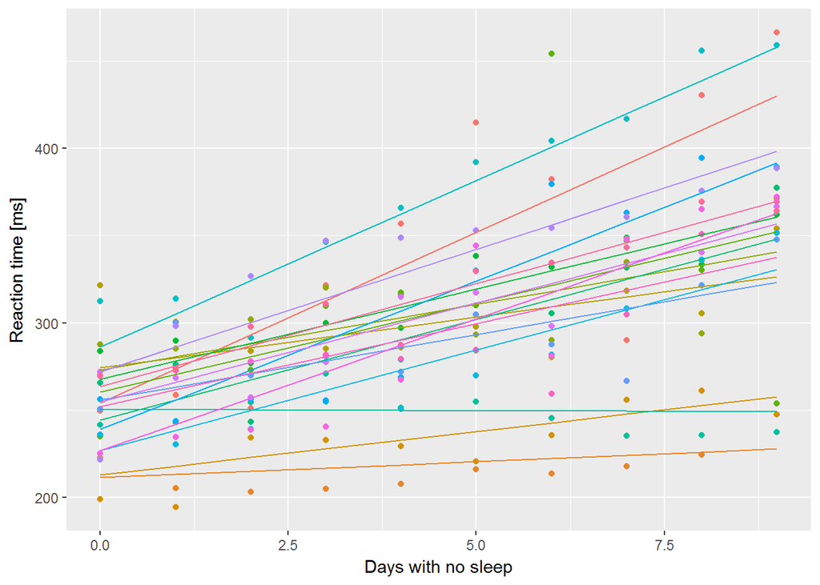

```r
# x is inherited from ssBase if we don't specify color=Subject in
# geom_line() we only get one line ... oh, because I specified color=Subject
# in geom_points() not ggplot()
ssBase + geom_line(aes(y = .fitted, color = Subject), data = ss.fitted) + guides(color = FALSE)
```

So each line represents the fitted values including the effects of the random perturbations on the intercept and slope. Now get the population level predictions using predict() and a new data.frame.

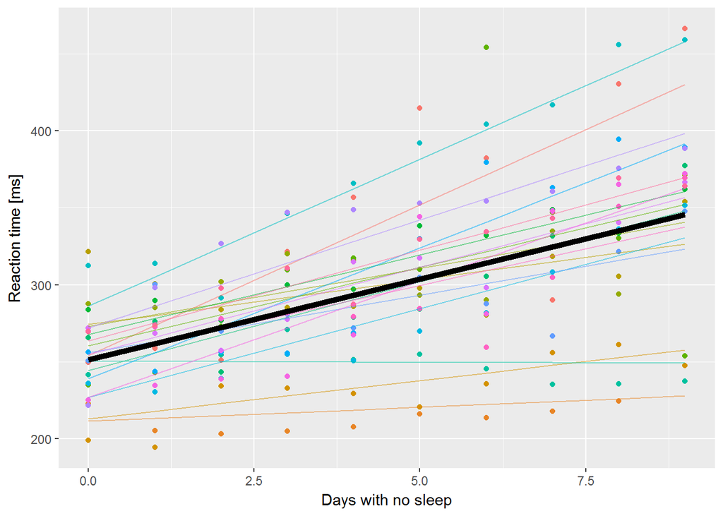

Reaction time as a function of days without sleep. Fine lines are subject level fitted values, thick black line is the population level prediction.

```r
nd <- data.frame(Days = 0:9)
# re.form tells predict what to do with the random effects ~0 says ignore
# them; population level predictions
nd$PopPred <- predict(ss.mm, newdata = nd, re.form = ~0)
ssBase + geom_line(aes(y = .fitted, color = Subject), data = ss.fitted, alpha = 0.5) +
    geom_line(aes(y = PopPred), data = nd, size = 2) + guides(color = FALSE)
```

OK, but we want to know how much confidence to have in that prediction. Really the only option here is to use bootstrapping. This is slow, but gets all the uncertainty in our prediction. Fortunately `lme4` includes a function `bootMer` to do bootstrapping by generating a random sample of data and then fitting the model to that new data. Repeat that 1000’s of times and you can get a distribution of possible model fits. Unfortunately we have to write a function to extract the predictions from the random samples the way we want them. Start by getting a single random sample.

```r
# bootMer takes a fitted merMod object then the function that takes a fitted
# merMod object and returns the thing we want as a vector fitted() will give
# us the coefficients from a fit
test <- bootMer(ss.mm, fixef)
# a (fairly) compact look at the *str*ucture of an object
str(test)
```

```
## List of 10
##  $ t0       : Named num [1:2] 251.4 10.5
##   ..- attr(*, "names")= chr [1:2] "(Intercept)" "Days"
##  $ t        : num [1, 1:2] 252.5 10.3
##   ..- attr(*, "dimnames")=List of 2
##   .. ..$ : NULL
##   .. ..$ : chr [1:2] "(Intercept)" "Days"
##  $ R        : int 1
##  $ data     :'data.frame':   180 obs. of  3 variables:
##   ..$ Reaction: num [1:180] 250 259 251 321 357 ...
##   ..$ Days    : num [1:180] 0 1 2 3 4 5 6 7 8 9 ...
##   ..$ Subject : Factor w/ 18 levels "308","309","310",..: 1 1 1 1 1 1 1 1 1 1 ...
##   ..- attr(*, "terms")=Classes 'terms', 'formula'  language Reaction ~ Days + (1 + Days + Subject)
##   .. .. ..- attr(*, "variables")= language list(Reaction, Days, Subject)
##   .. .. ..- attr(*, "factors")= int [1:3, 1:2] 0 1 0 0 0 1
##   .. .. .. ..- attr(*, "dimnames")=List of 2
##   .. .. .. .. ..$ : chr [1:3] "Reaction" "Days" "Subject"
##   .. .. .. .. ..$ : chr [1:2] "Days" "Subject"
##   .. .. ..- attr(*, "term.labels")= chr [1:2] "Days" "Subject"
##   .. .. ..- attr(*, "order")= int [1:2] 1 1
##   .. .. ..- attr(*, "intercept")= int 1
##   .. .. ..- attr(*, "response")= int 1
##   .. .. ..- attr(*, ".Environment")=<environment: R_GlobalEnv>
##   .. .. ..- attr(*, "predvars")= language list(Reaction, Days, Subject)
##   .. .. ..- attr(*, "dataClasses")= Named chr [1:3] "numeric" "numeric" "factor"
##   .. .. .. ..- attr(*, "names")= chr [1:3] "Reaction" "Days" "Subject"
##   .. .. ..- attr(*, "predvars.fixed")= language list(Reaction, Days)
##   .. .. ..- attr(*, "predvars.random")= language list(Reaction, Days, Subject)
##   ..- attr(*, "formula")=Class 'formula'  language Reaction ~ Days + (1 + Days | Subject)
##   .. .. ..- attr(*, ".Environment")=<environment: R_GlobalEnv>
##  $ seed     : int [1:626] 403 433 50027432 238952363 1520954569 -1164362536 1933640070 -1093101471 1044781555 -1130624926 ...
##  $ statistic:function (object, ...)
##  $ sim      : chr "parametric"
##  $ call     : language bootMer(x = ss.mm, FUN = fixef)
##  $ ran.gen  : chr "simulate(<lmerMod>, 1, *)"
##  $ mle      :List of 3
##   ..$ beta : num [1:2] 251.4 10.5
##   ..$ theta: Named num [1:3] 0.9292 0.0182 0.2226
##   .. ..- attr(*, "names")= chr [1:3] "Subject.(Intercept)" "Subject.Days.(Intercept)" "Subject.Days"
##   ..$ sigma: num 25.6
##  - attr(*, "class")= chr "boot"
##  - attr(*, "bootFail")= int 0
```

There’s alot of stuff in there, most of which relates to internal stuff that would allow us to recreate the simulation. We are mostly interested in `t0` and `t`. `t0` is the result of applying our FUN to the original object. In this case it gives us a vector of the fixed effects coefficients. `t` is a matrix of the simulation output. In each row is the result of our FUN applied to a simulated result. By default `bootMer` only does one simulation. If we want more:

```r
test <- bootMer(ss.mm, fixef, nsim = 10)
test$t
```

```
##       (Intercept)      Days
##  [1,]    252.1641 12.897530
##  [2,]    242.6911 10.585926
##  [3,]    253.5514 11.649575
##  [4,]    247.4915  9.098195
##  [5,]    255.3459 12.400746
##  [6,]    254.3473 11.552463
##  [7,]    250.8250  9.016578
##  [8,]    251.2591  9.005365
##  [9,]    259.9961 10.708251
## [10,]    254.3581 10.222667
```

If we set `nsim = 10000` and then took quantiles of the resulting columns, we could get bootstrapped confidence limits on our fixed effects. That’s what is happening when we do `confint(ss.mm, method="boot")`. We want a function that makes a prediction from a fitted model. Just using `predict()` won’t work, because the function only takes one argument, the fitted model. So we have to make a “wrapper” that will call `predict()` with the right arguments.

```r
myFunc <- function(mm) {
    # forgot the re.form argument on first try
    predict(mm, newdata = nd, re.form = ~0)
}
myFunc(ss.mm)  # works
```

```
##        1        2        3        4        5        6        7        8
## 251.4051 261.8724 272.3397 282.8070 293.2742 303.7415 314.2088 324.6761
##        9       10
## 335.1434 345.6107
```

```r
# try with bootMer()
test <- bootMer(ss.mm, myFunc)
test$t  #works
```

```
##             1        2        3        4        5        6        7
## [1,] 244.2302 254.4655 264.7008 274.9361 285.1715 295.4068 305.6421
##             8        9      10
## [1,] 315.8774 326.1127 336.348
```

OK, this next bit takes a while … about 1 minute on my (old) home computer

```r
bigBoot <- bootMer(ss.mm, myFunc, nsim = 1000)
head(bigBoot$t)
```

```
##             1        2        3        4        5        6        7
## [1,] 245.8533 256.3718 266.8903 277.4089 287.9274 298.4459 308.9644
## [2,] 252.8311 263.2781 273.7250 284.1719 294.6189 305.0658 315.5128
## [3,] 263.1639 272.9675 282.7710 292.5745 302.3780 312.1815 321.9850
## [4,] 243.5371 254.6773 265.8176 276.9578 288.0981 299.2383 310.3786
## [5,] 255.3335 264.4713 273.6091 282.7469 291.8847 301.0225 310.1603
## [6,] 239.2752 251.0024 262.7296 274.4568 286.1840 297.9112 309.6383
##             8        9       10
## [1,] 319.4829 330.0014 340.5200
## [2,] 325.9597 336.4067 346.8536
## [3,] 331.7886 341.5921 351.3956
## [4,] 321.5188 332.6591 343.7993
## [5,] 319.2981 328.4359 337.5737
## [6,] 321.3655 333.0927 344.8199
```

Now we want quantiles of each column of that thing, turned around so the columns are rows like the original `nd`.

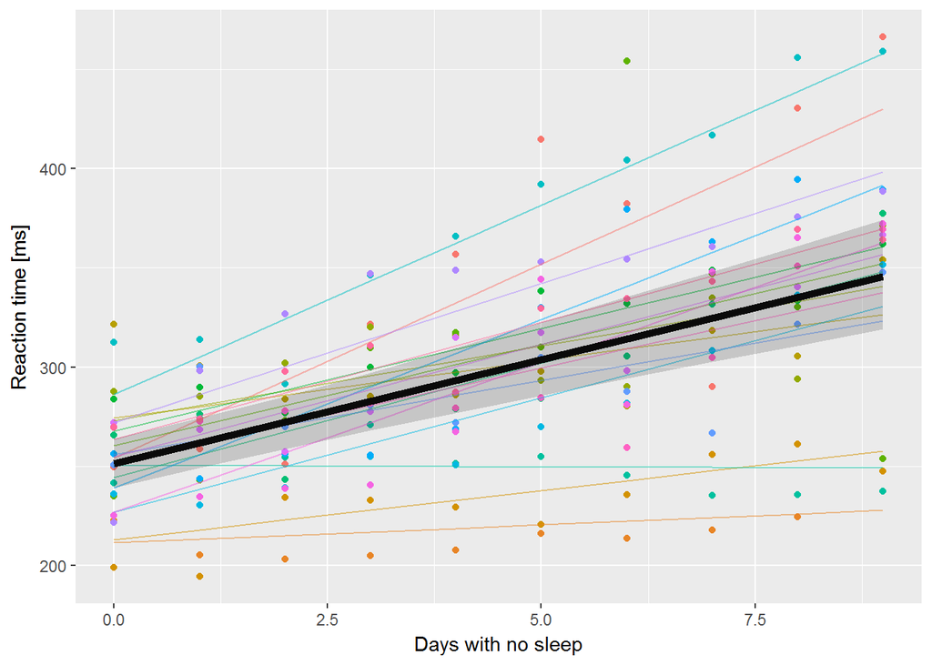

```r
# apply(xx, MARGIN = 2, FUN, ...) 'applies' FUN to each column (because
# MARGIN = 2). arguments in ... get passed to FUN t() transposes the result
predCL <- t(apply(bigBoot$t, MARGIN = 2, FUN = quantile, probs = c(0.025, 0.975)))
# ggplot only works with data.frames so add to nd '%' in column names is a
# disaster so be explicit
nd$lci <- predCL[, 1]
nd$uci <- predCL[, 2]

ssBase + geom_line(aes(y = .fitted, color = Subject), data = ss.fitted, alpha = 0.5) +
    geom_line(aes(y = PopPred), data = nd, size = 2) + geom_ribbon(aes(x = Days,
    ymin = lci, ymax = uci), data = nd, inherit.aes = FALSE, alpha = 0.2) +
    guides(color = FALSE)
```

So that’s pretty nice. I can add a geom_smooth() to show how much wider the confidence intervals are compared to ignoring all the extra variability.

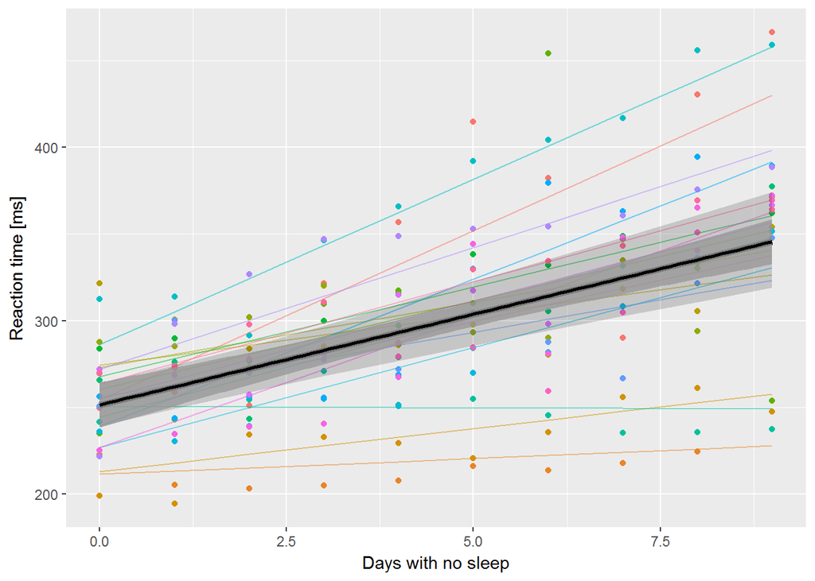

Reaction time as a function of days without sleep. Fine lines are subject level fits, thick line is population level prediction. The outer ribbon are bootstrapped 95% confidence limits. The inner ribbon is a 95% confidence limit ignoring between subject variation and random effects uncertainty.

```r
ssBase + geom_line(aes(y = .fitted, color = Subject), data = ss.fitted, alpha = 0.5) +
    geom_line(aes(y = PopPred), data = nd, size = 2) + # set inherit.aes to FALSE here otherwise geom_ribbon looks for a y
# aesthetic called Reaction
geom_ribbon(aes(x = Days, ymin = lci, ymax = uci), data = nd, inherit.aes = FALSE,
    alpha = 0.2) + geom_smooth(method = "lm", alpha = 0.8, color = "black") +
    guides(color = FALSE)
```

It is interesting that there isn’t much difference when Days == 0. Note that you wouldn’t ever do this in practice! However, it might be nice to build a few polygons at different levels of confidence.

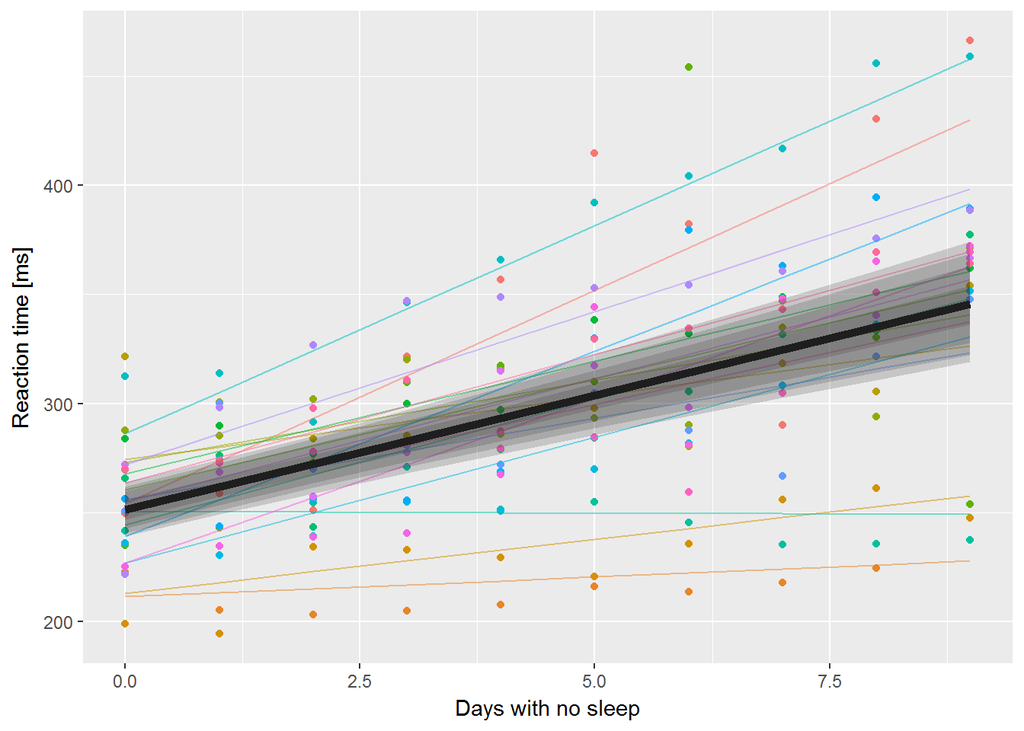

Adding multiple transparent ribbons to match 95%, 90%, 80% and 50% confidence limits.

```r
predCL <- t(apply(bigBoot$t, MARGIN = 2, FUN = quantile, probs = c(0.05, 0.95,
    0.1, 0.9, 0.25, 0.75)))
# try making it into a dataframe
predCL <- data.frame(predCL)
# names(predCL) so puts a X at the front bc can't start with a number, and
# replaces % with .  put them into nd
nd <- bind_cols(nd, predCL)
# brute force multi-ribbons:
ssBase + geom_line(aes(y = .fitted, color = Subject), data = ss.fitted, alpha = 0.5) +
    geom_line(aes(y = PopPred), data = nd, size = 2) + # set inherit.aes to FALSE here otherwise geom_ribbon looks for a y
# aesthetic called Reaction
geom_ribbon(aes(x = Days, ymin = lci, ymax = uci), data = nd, inherit.aes = FALSE,
    alpha = 0.2) + # add 90% ribbon
geom_ribbon(aes(x = Days, ymin = X5., ymax = X95.), data = nd, inherit.aes = FALSE,
    alpha = 0.2) + # add 80% ribbon
geom_ribbon(aes(x = Days, ymin = X10., ymax = X90.), data = nd, inherit.aes = FALSE,
    alpha = 0.2) + # add 50% ribbon
geom_ribbon(aes(x = Days, ymin = X25., ymax = X75.), data = nd, inherit.aes = FALSE,
    alpha = 0.2) +
guides(color = FALSE)
```

That doesn’t look as good as I’d hoped. The idea here is to draw the eye closer to the expected value rather than the outer edges of the confidence region.

## Doing it with a glmm

So now we want to redo the deer model from last week.

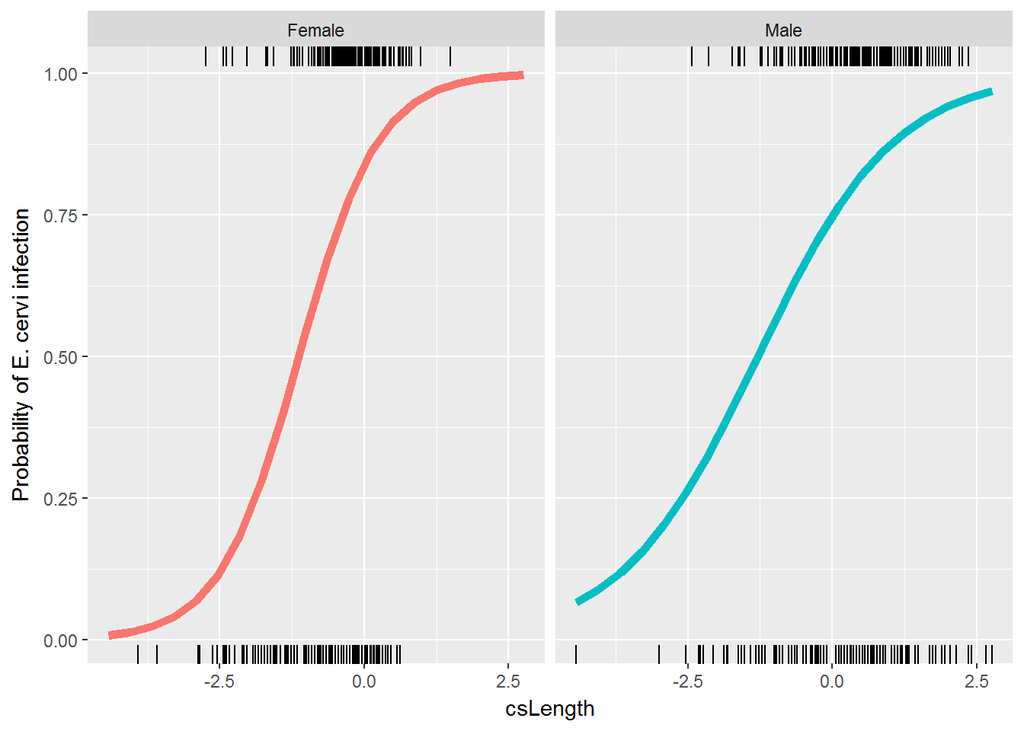

```r
ecervi = read.table("data/deerecervi.txt", header = TRUE)
ecervi <- ecervi %>% mutate(Ecervi.pa = Ecervi > 0, fSex = factor(Sex, labels = c("Male",
    "Female")), cLength = Length - mean(Length), csLength = cLength/sd(Length))

contrasts(ecervi$fSex) <- contr.sum(2)

M0 <- glmer(Ecervi.pa ~ fSex * csLength + (1 + csLength | Farm), data = ecervi,
    family = binomial)

lr = range(ecervi$csLength)
nd <- expand.grid(csLength = seq(lr[1], lr[2], length = 20), fSex = factor(levels(ecervi$fSex)))

nd$pp = predict(M0, newdata = nd, type = "response", re.form = ~0)

ggplot(nd, aes(x = csLength, y = pp, col = fSex)) + geom_line(alpha = 0.5) +
    ylab("Probability of E. cervi infection") + geom_line(aes(x = csLength,
    y = pp, col = fSex), data = nd, inherit.aes = FALSE, size = 2) + geom_rug(aes(x = csLength),
    data = filter(ecervi, Ecervi.pa), sides = "t", inherit.aes = FALSE) + geom_rug(aes(x = csLength),
    data = filter(ecervi, !Ecervi.pa), sides = "b", inherit.aes = FALSE) + facet_wrap(~fSex) +
    guides(color = FALSE)
```

I like this one with `facet_wrap()` better than the one from last week. OK, now we want to do the bootstrap. But fitting this model already is slow, so doing it 1000 times is even slower! Bootstrapping is one of the things that benefits from parallel computing very easily. The bit of code below sets up a “cluster” on my computer and splits the computation up 4 ways. 4 times faster. Most modern CPU’s have multiple cores that can run independently. In normal operation R uses just one core. My office computer has **8** cores, so could speed up this computation by a factor of 8! Although it doesn’t appear to be working with the following code, not sure why.

```r
# Don't run this code!  this package sets up the cluster
library(snow)
cl <- makeCluster(4, type = "SOCK")
# now we pass the cluster object to bootMer note that I can use the same
# myFunc!
bigBoot2 <- bootMer(M0, myFunc, nsim = 1000, parallel = "snow", cl = cl)
stopCluster(cl)  ## hmmm, makeCluster doesn't appear to be working
# takes a loooong time ...
save(bigBoot2, file = "data/bigBoot2.RData")
```

```r
# remember to download the bigBoot2.RData file
if (!exists("bigBoot2")) {
    load("data/bigBoot2.Rdata")
}
# the object returned by bootMer is of type boot and there are some useful
# functions there.
envPred <- envelope(bigBoot2)
str(envPred)
```

```
## List of 7
##  $ point  : num [1:2, 1:40] -0.93 -4.534 -0.739 -4.02 -0.544 ...
##   ..- attr(*, "dimnames")=List of 2
##   .. ..$ : NULL
##   .. ..$ : chr [1:40] "1" "2" "3" "4" ...
##  $ overall: num [1:2, 1:40] -0.496 -5.418 -0.332 -4.89 -0.168 ...
##   ..- attr(*, "dimnames")=List of 2
##   .. ..$ : NULL
##   .. ..$ : chr [1:40] "1" "2" "3" "4" ...
##  $ k.pt   : num [1:2] 25 976
##  $ err.pt : num [1:2] 0.05 0.241
##  $ k.ov   : num [1:2] 3 998
##  $ err.ov : num [1:2] 0.00599 0.04396
##  $ err.nom: num [1:2] 0.05 0.05
```

The matrix `point` in there is the “pointwise” 95% confidence intervals for each of the 40 rows in `nd`. The error rate for those intervals is 5% on each value, which means that 24% of the points will be outside the interval over the entire curve. The matrix `overall` expands those limits until the number of points over the entire curve is 5%. Time to add these to a plot. First we have to get them into the nd data.frame.

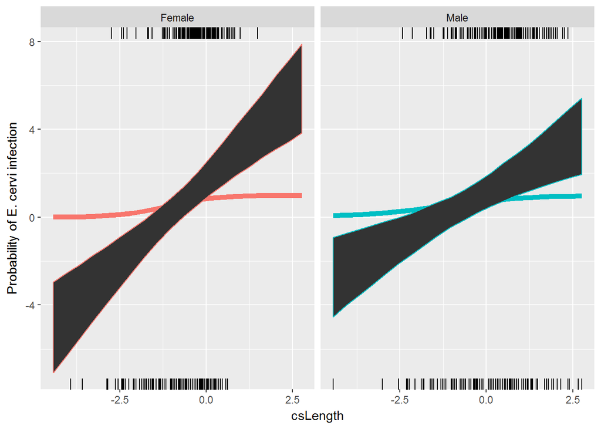

```r
nd$lower.point <- envPred$point[1, ]
nd$upper.point <- envPred$point[2, ]
ggplot(nd, aes(x = csLength, y = pp, col = fSex)) + geom_line(alpha = 0.5) +
    ylab("Probability of E. cervi infection") + geom_line(aes(x = csLength,
    y = pp, col = fSex), data = nd, inherit.aes = FALSE, size = 2) + geom_rug(aes(x = csLength),
    data = filter(ecervi, Ecervi.pa), sides = "t", inherit.aes = FALSE) + geom_rug(aes(x = csLength),
    data = filter(ecervi, !Ecervi.pa), sides = "b", inherit.aes = FALSE) + geom_ribbon(aes(x = csLength,
    ymin = lower.point, ymax = upper.point, color = fSex), data = nd, inherit.aes = FALSE) +
    facet_wrap(~fSex) + guides(color = FALSE)
```

And in fact they aren’t. Back when we created `myFunc()`, we just used `predict()` without specifying the argument `type` (think back to week 5 & 6 with `glm()` fits). By default, `predict()` produces values on the link scale, the scale of the linear predictor part of the model. But we want to plot probabilities, so we have two choices.

1. change myFunc to use `type="response"` and rerun `bootMer()`
2. transform the link scale values to probabilities with the logistic function.

I’m going with (2), because it took hours to do (1) the first time.

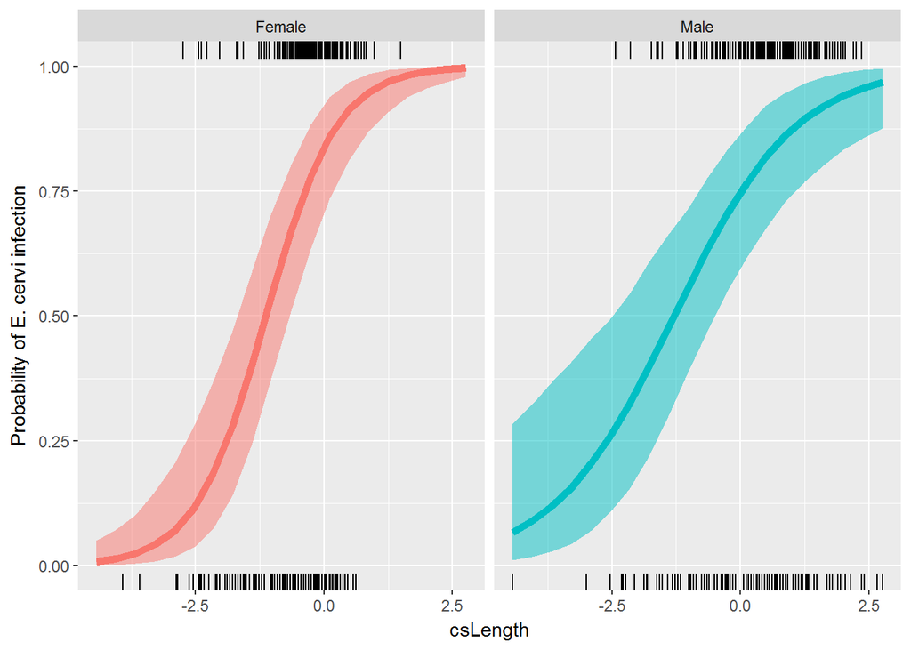

```r
# boot::inv.logit() does the job
nd$lower.point <- inv.logit(envPred$point[1, ])
nd$upper.point <- inv.logit(envPred$point[2, ])
ggplot(nd, aes(x = csLength, y = pp, col = fSex)) + # and don't forget to change alpha
geom_ribbon(aes(x = csLength, ymin = lower.point, ymax = upper.point, fill = fSex),
    data = nd, inherit.aes = FALSE, alpha = 0.5) + geom_line(aes(col = fSex),
    alpha = 0.5) + ylab("Probability of E. cervi infection") + geom_line(aes(x = csLength,
    y = pp, col = fSex), data = nd, inherit.aes = FALSE, size = 2) + geom_rug(aes(x = csLength),
    data = filter(ecervi, Ecervi.pa), sides = "t", inherit.aes = FALSE) + geom_rug(aes(x = csLength),
    data = filter(ecervi, !Ecervi.pa), sides = "b", inherit.aes = FALSE) + facet_wrap(~fSex) +
    guides(color = FALSE, fill = FALSE)
```

Phew! The reason this lab is so late getting up is that I could not get that d#$(*&#) graph to have matching colors on the line and the fill. I spent a couple of hours trying everything I could think of. As it turns out it was failing because I had copied the graph code, but not changed the object names … and because I was working interactively the old objects were still around! I only realized my error after wiping the workspace and running the script from the top. The moral of the story is, when nothing makes sense, take it from the top!

1. Redo the plot with the “overall” 95% confidence limits and compare with the previous plot. Does that change your inference?